# Внешний курс. Блок 3

Основы информационной безопасности

Краснова К. Г., НКАбд-03-24

Российский университет дружбы народов, Москва, Россия

17 февраля 2026

# Цель работы

Пройти третий блок курса “Основы кибербезопасности”

# Выполнение блока 3: Криптография на практике

## Введение в криптографию

Для ответа на вопрос используется определение ассмиетричного шифрования с двумя ключами (рис. [-@fig:001]).

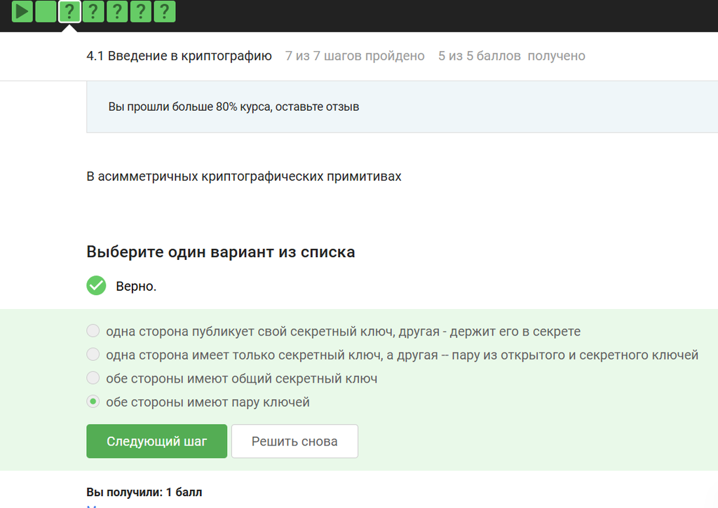

Вопрос 4.1.1

## Введение в криптографию

Отмечены основные условия для криптографической хэш-функции (рис. [-@fig:002]).

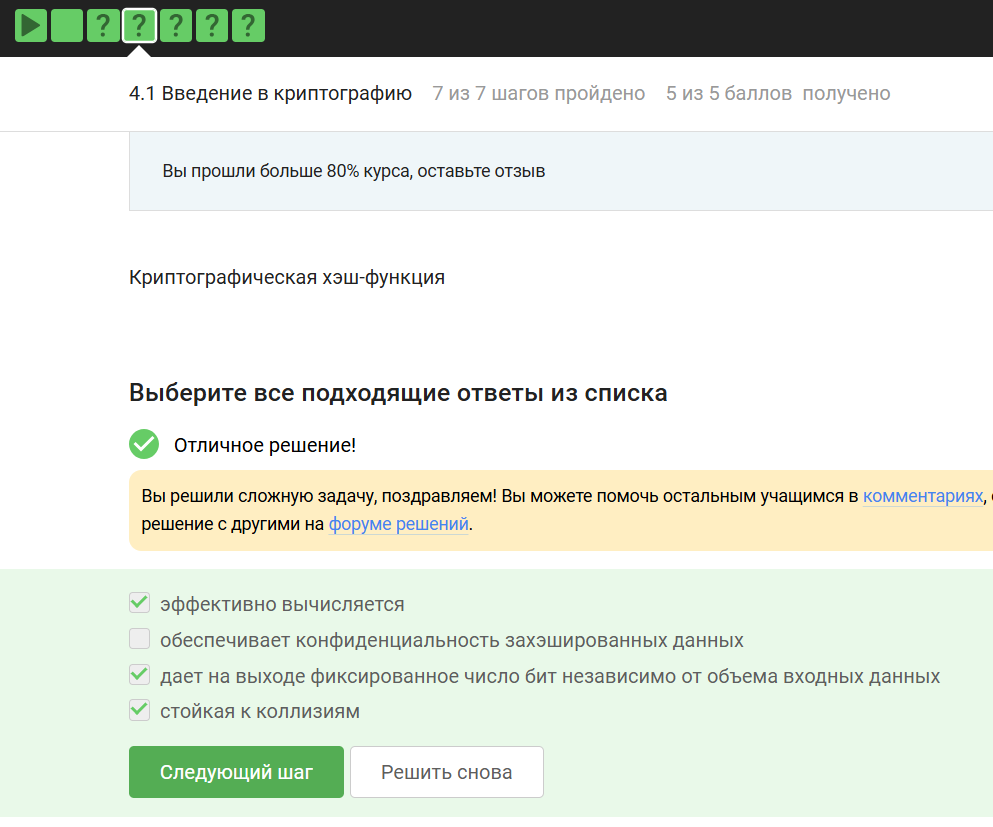

Вопрос 4.1.2

## Введение в криптографию

Отмечены алгоритмы цифровой подписи (рис. [-@fig:003]).

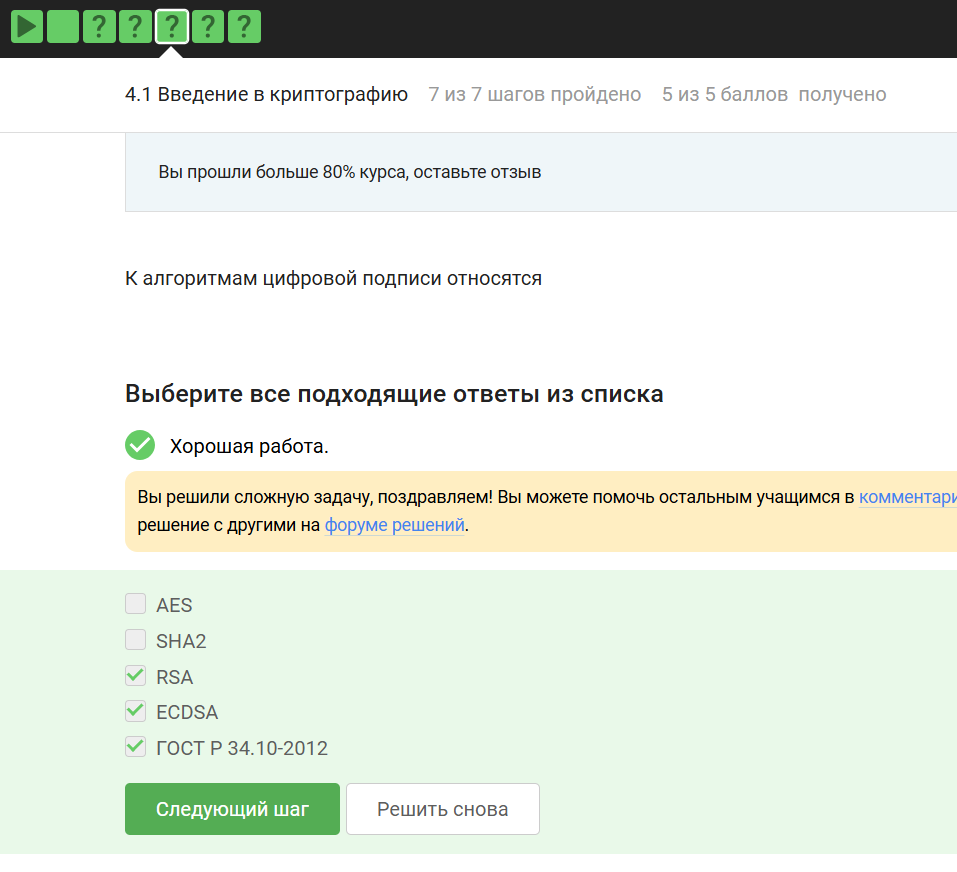

Вопрос 4.1.3

## Введение в криптографию

В информационной безопасности аутентификация сообщения или аутентификация источника данных-это свойство, которое гарантирует, что сообщение не было изменено во время передачи (целостность данных) и что принимающая сторона может проверить источник сообщения (рис. [-@fig:004])

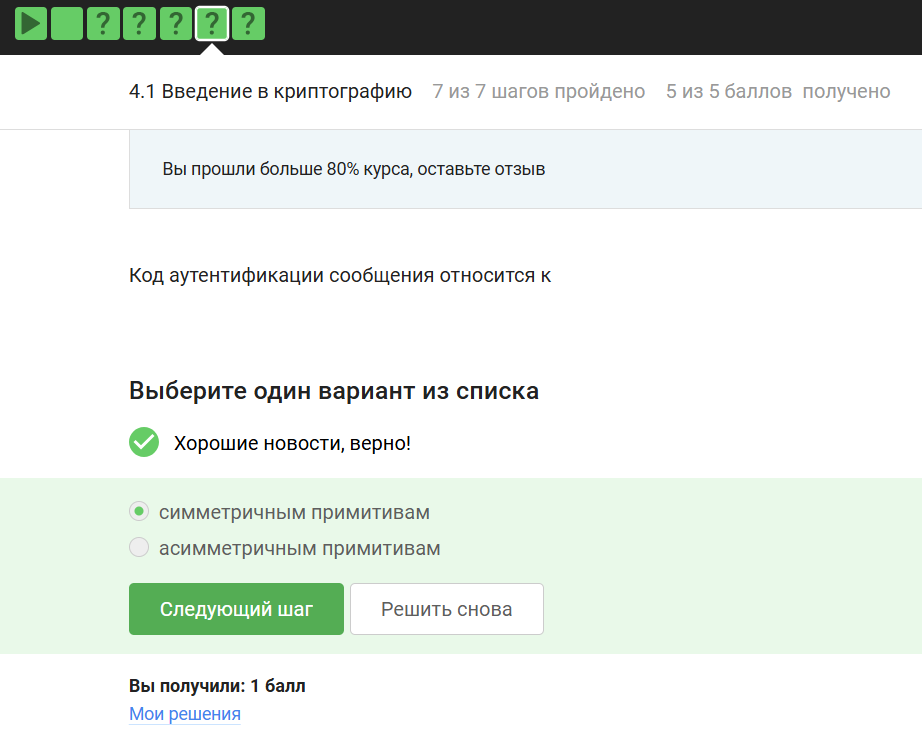

Вопрос 4.1.4

## Введение в криптографию

Определение обмена ключами Диффи-Хэллмана. (рис. [-@fig:005]).

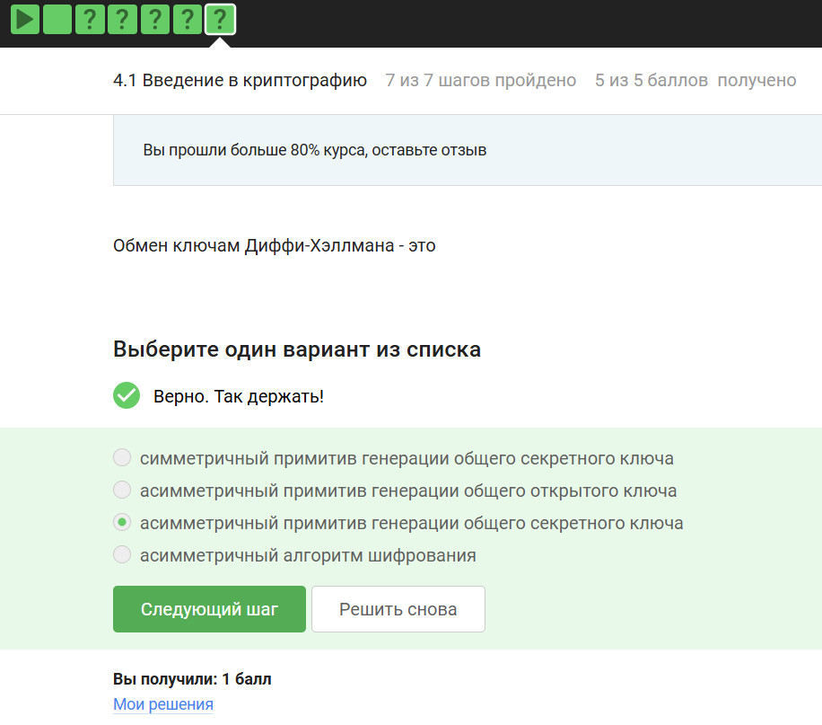

Вопрос 4.1.5

## Цифровая подпись

По определению цифровой подписи протокол ЭЦП относится к протоколам с публичным ключом (рис. [-@fig:006]).

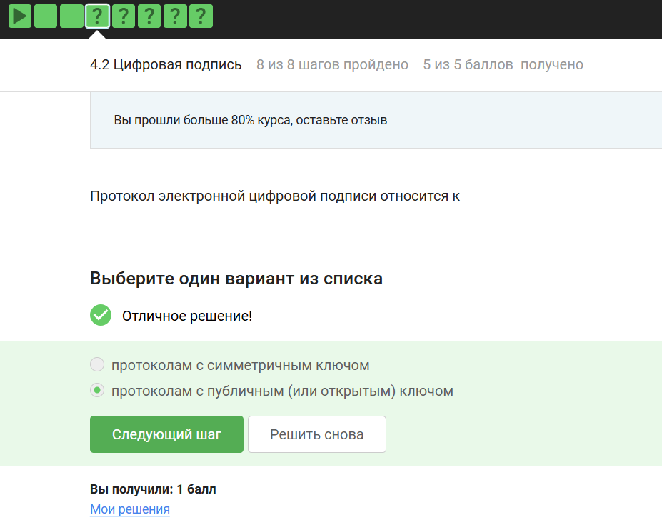

Вопрос 4.2.1

## Цифровая подпись

лгоритм верификации электронной подписи состоит в следующем. На первом этапе получатель сообщения строит собственный вариант хэш-функции подписанного документа. На втором этапе происходит расшифровка хэш-функции, содержащейся в сообщении с помощью открытого ключа отправителя. На третьем этапе производится сравнение двух хэш- функций. Их совпадение гарантирует одновременно подлинность содержимого документа и его авторства (рис. [-@fig:007]).

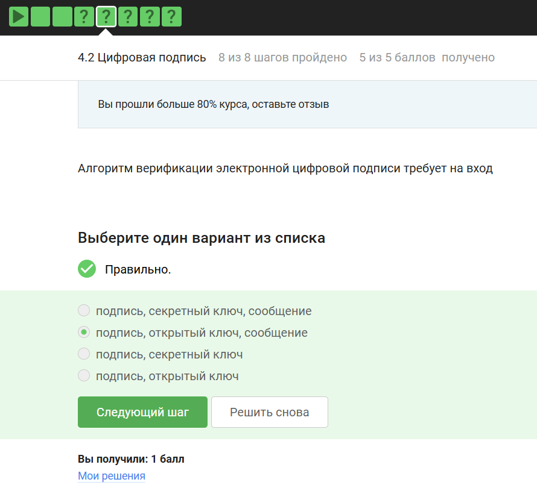

Вопрос 4.2.2

## Цифровая подпись

Электронная подпись обеспечивает все указанное, кроме конфиденциальности (рис. [-@fig:008]).

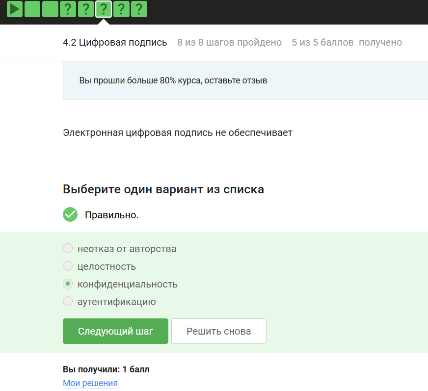

Вопрос 4.2.3

## Цифровая подпись

Для отправки налоговой отчетности в ФНС используется усиленная квалифицированная электронная подпись (рис. [-@fig:009]).

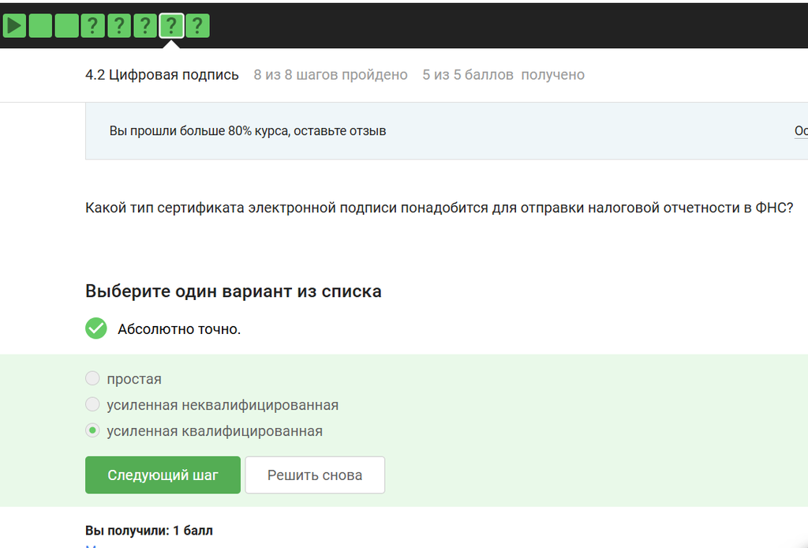

Вопрос 4.2.4

## Цифровая подпись

Верный ответ укзаан на изображении (рис. [-@fig:010]).

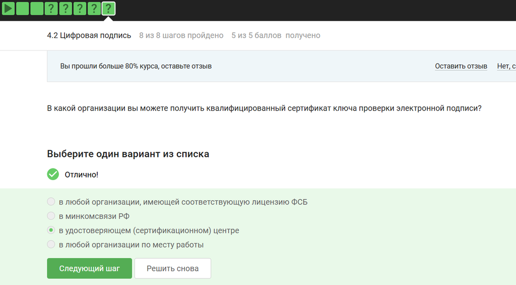

Вопрос 4.2.5

## Электронные платежи

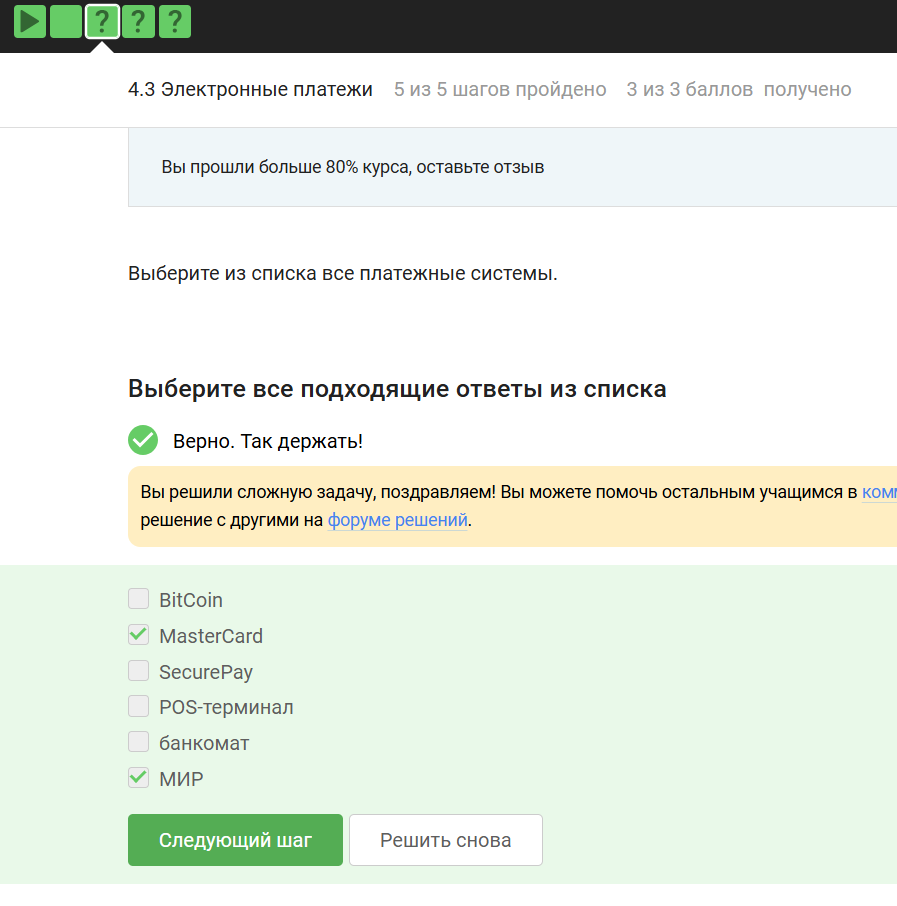

Вопрос 4.3.1

## Электронные платежи

Верный ответ на изображении (рис. [-@fig:012]).

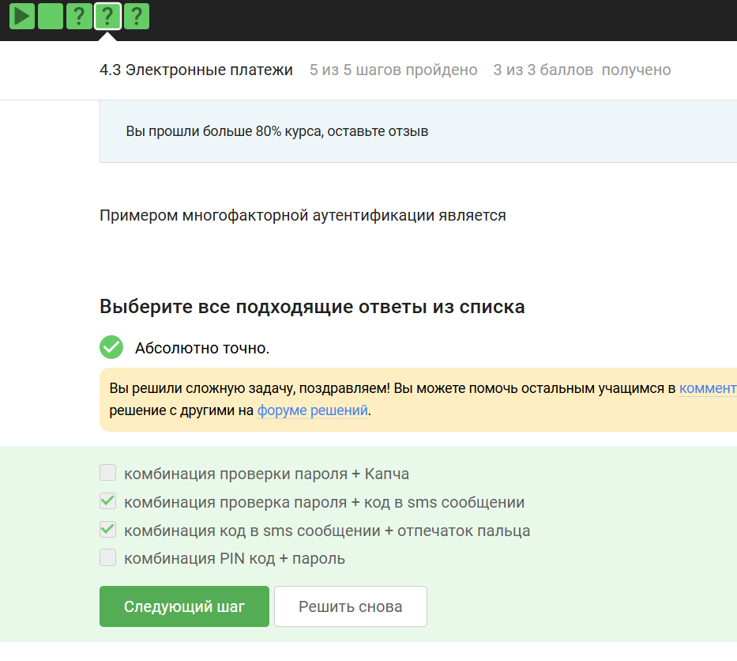

Вопрос 4.3.2

## Электронные платежи

При онлайн платежах используется многофакторная аутентификация (рис. [-@fig:013]).

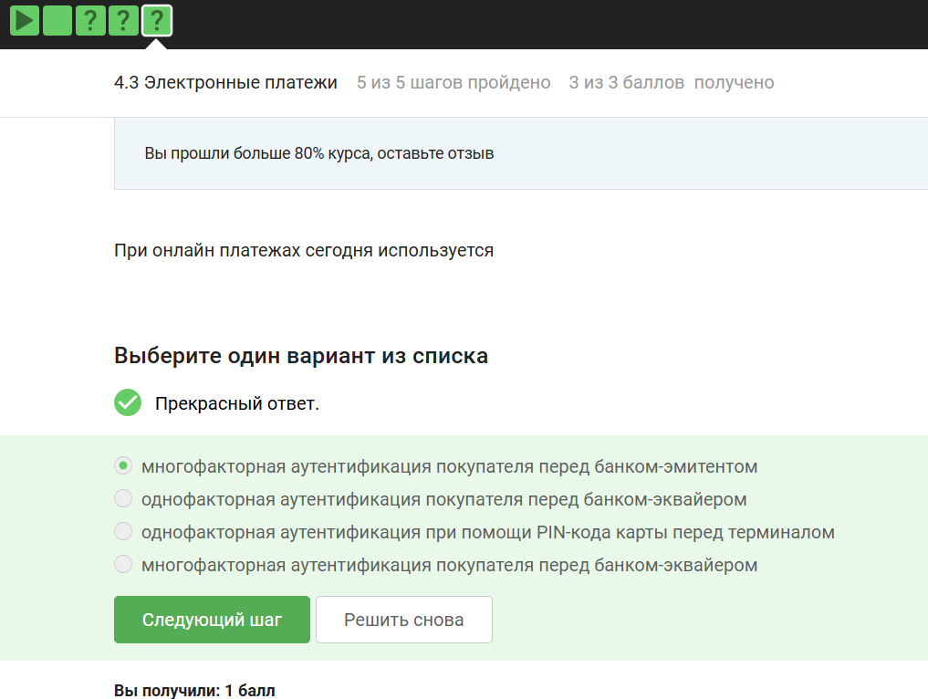

Вопрос 4.3.3

## Блокчейн

Proof-of-Work, или PoW, (доказательство выполнения работы) — это алгоритм достижения консенсуса в блокчейне; он используется для подтверждения транзакций и создания новых блоков. С помощью PoW майнеры конкурируют друг с другом за завершение транзакций в сети и за вознаграждение. Пользователи сети отправляют друг другу цифровые токены, после чего все транзакции собираются в блоки и записываются в распределенный реестр, то есть в блокчейн. (рис. [-@fig:014]).

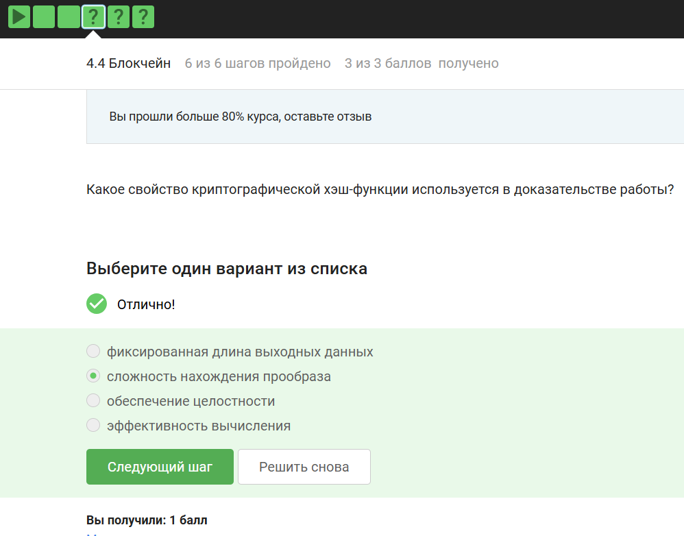

Вопрос 4.4.1

## Блокчейн

Консенсус блокчейна — это процедура, в ходе которой участники сети достигают согласия о текущем состоянии данных в сети. Благодаря этому алгоритмы консенсуса устанавливают надежность и доверие к самоу сети. (рис. [-@fig:015]).

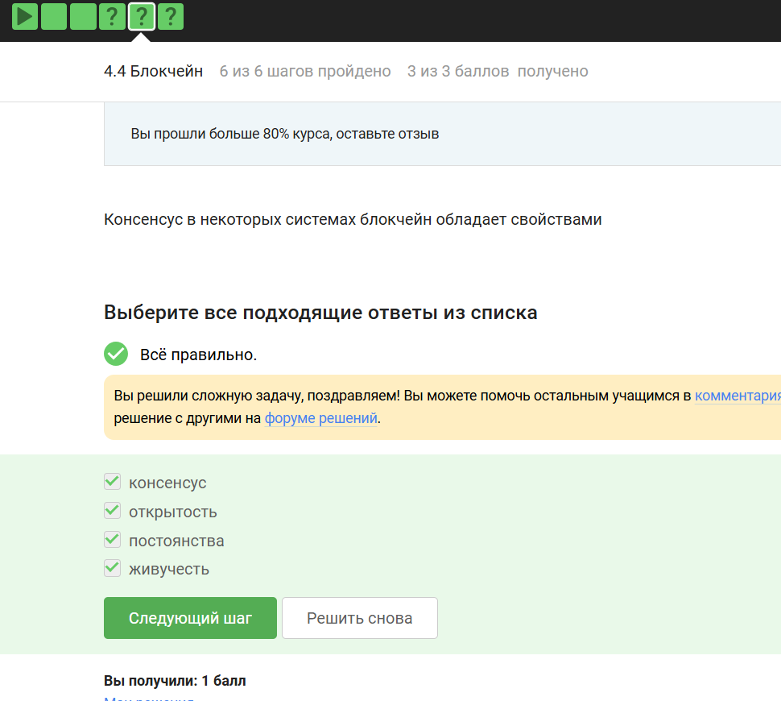

Вопрос 4.4.2

## Блокчейн

Ответ - цифровая подпись (рис. [-@fig:016]).

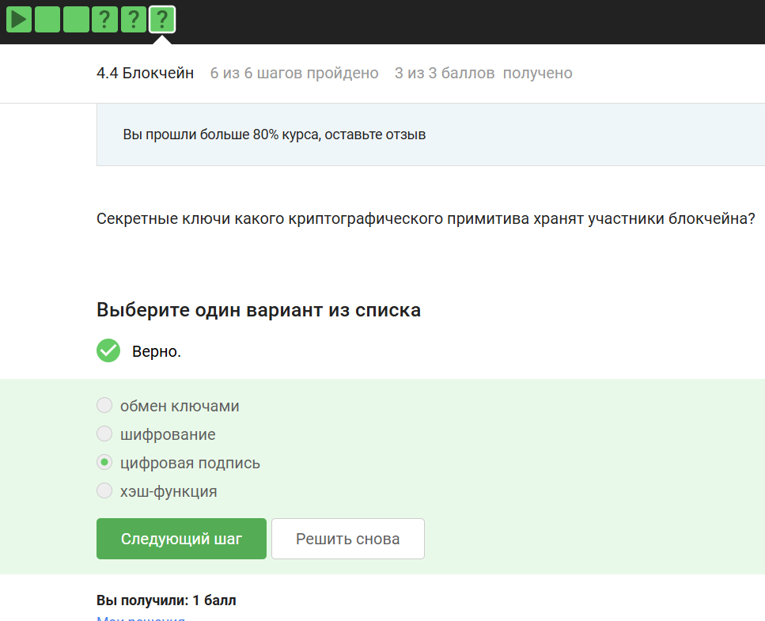

Вопрос 4.4.3

# Выводы

Я прошла третий блок